# Embedded Inference Client API

5.2.0  
Embedded Inference Client API

- [ Index ]
- Introduction
  - Getting started
  - AI buffers and privileged placement
  - I/O buffers inside the “activations” buffer
  - Split weights buffer
  - Re-entrance and thread safety considerations
  - Debug support
- Embedded Client API
  - `AI_<NAME>_XXX` C-defines
  - `ai_<name>_create()`
  - `ai_<name>_init()`
  - `ai_<name>_run()`
  - `ai_<name>_get_error()`
  - `ai_<name>_get_info()`
- IO buffer/tensor description
  - ai_buffer C-struct
  - Tensor format
  - Life-cycle of the IO buffers
  - Base address of the IO buffers
  - Float to integer format conversion
  - Integer to float format conversion
  - Float to Qmn format conversion
  - Qmn to float format conversion
  - 1d-array tensor
  - 2d-array tensor
  - 3d-array tensor
- Platform Observer API
  - User call-back registration for profiling use-case
  - Node-per-node inspection
  - Copy-before-run use-case
  - Dumping intermediate output use-case
  - End-of-process input buffer notification use-case
  - “ai_observer_node” definition
  - `ai_platform_observer_node_info()`
  - `ai_platform_observer_register()`
- References
- Revision history

# Embedded Inference Client API

X-CUBE-AI Expansion Package

r2.2

AI PLATFORM r5.2.0 (Embedded Inference Client API 1.1.0)

Command Line Interface r1.4.0

# Introduction

This article describes the embedded inference client API (`ai_<name>_XXX()` functions) which must be used by a C-application layer (AI client) to use a deployed C-model. All model-specific definitions and implementations can be found in the specialized NN C-files: `'<name>.c'` and `'<name>.h'` (refer to [[2], *“Generated STM32 NN library”*](https://www.st.com/resource/en/user_manual/dm00570145.pdf) section). A Platform observer API for debug, advanced use-cases and profiling purposes is also described.

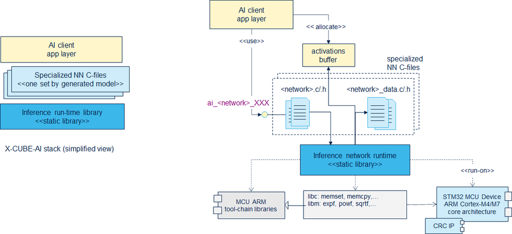

Figure 1: MCU integration model/view and dependencies

Above figure shows that the integration of the AI stack in an application stack is simple and straightforward. There is only few and standard dependencies with the run-time (SW and/or HW). Only STM32 CRC IP should be clocked to be able to use the inference runtime library. AI client uses the generated model only through the generated well-defined `ai_<name>_XXX()` functions (also called *“Embedded Inference Client API”*). The X-CUBE-AI pack provides a compiled library (network runtime library) by STM32 series and by supported tool-chains.

## Getting started

The following code snippet provides a typical and minimal example using the API for a 32b float model. The pre-trained model is generated with the default options i.e. input buffer is not allocated in the “activations” buffer and default c-name (`'network'`) is used. Note that all AI requested client resources (activations buffer and data buffers for the IO) are allocated at compile time thanks the generated macros: `'AI_NETWORK_XXX_SIZE'` allowing a minimalist, easier and quick integration.

```c
#include <stdio.h>

#include "network.h"
#include "network_data.h"

/* Global handle to reference an instantiated C-model */
static ai_handle network = AI_HANDLE_NULL;

/* Global c-array to handle the activations buffer */
AI_ALIGNED(4)
static ai_u8 activations[AI_NETWORK_DATA_ACTIVATIONS_SIZE];

/* Data payload for input tensor */
AI_ALIGNED(4)
static ai_float in_data[AI_NETWORK_IN_1_SIZE];
/* or static ai_u8 in_data[AI_NETWORK_IN_1_SIZE_BYTES]; */

/* Data payload for the output tensor */
AI_ALIGNED(4)
static ai_float out_data[AI_NETWORK_OUT_1_SIZE];
/* static ai_u8 out_data[AI_NETWORK_OUT_1_SIZE_BYTES]; */

/*
 * Bootstrap code
 */
int aiInit(void) {
  ai_error err;

  /* 1 - Create an instance of the model */
  err = ai_network_create(&network, AI_NETWORK_DATA_CONFIG /* or NULL */);
  if (err.type != AI_ERROR_NONE) {
    printf("E: AI ai_network_create error - type=%d code=%d\r\n", err.type, err.code);
    return -1;
    };

  /* 2 - Initialize the instance */
  const ai_network_params params = {
      AI_NETWORK_DATA_WEIGHTS(ai_network_data_weights_get()),
      AI_NETWORK_DATA_ACTIVATIONS(activations) };

  if (!ai_network_init(network, &params)) {
      err = ai_network_get_error(network);
      printf("E: AI ai_network_init error - type=%d code=%d\r\n", err.type, err.code);
      return -1;
    }

  return 0;
}

/*
 * Run inference code
 */
int aiRun(const void *in_data, void *out_data)
{
  ai_i32 n_batch;
  ai_error err;

  /* 1 - Create the AI buffer IO handlers with the default definition */
  ai_buffer ai_input[AI_NETWORK_IN_NUM] = AI_NETWORK_IN ;
  ai_buffer ai_output[AI_NETWORK_OUT_NUM] = AI_NETWORK_OUT ;

  /* 2 - Update IO handlers with the data payload */
  ai_input[0].n_batches = 1;
  ai_input[0].data = AI_HANDLE_PTR(in_data);
  ai_output[0].n_batches = 1;
  ai_output[0].data = AI_HANDLE_PTR(out_data);

  /* 3 - Perform the inference */
  n_batch = ai_network_run(network, &ai_input[0], &ai_output[0]);
  if (n_batch != 1) {
      err = ai_network_get_error(network);
      printf("E: AI ai_network_run error - type=%d code=%d\r\n", err.type, err.code);
      return -1;
  };

  return 0;
}

/*
 * Example of main loop function
 */
void main_loop()
{
  /* The STM32 CRC IP clock should be enabled to use the network runtime library */
  __HAL_RCC_CRC_CLK_ENABLE();

  aiInit();

  while (1) {
    /* 1 - Acquire, pre-process and fill the input buffers */
    acquire_and_process_data(in_data);

    /* 2 - Call inference engine */
    aiRun(in_data, out_data);

    /* 3 - Post-process the predictions */
    post_process(out_data);
  }
}
```

Only the following `CFLAGS/LDFLAGS` extensions (Embedded GCC-based for ARM tool-chain) are requested to compile the specialized c-files and to add the inference runtime library in a STM32 Cortex-m4 based project.

```
CFLAGS += -mcpu=cortex-m4 -mthumb -mfpu=fpv4-sp-d16  -mfloat-abi=hard

CFLAGS += -IMiddlewares/ST/AI/Lib/Inc
LDFLAGS += -LMiddlewares/ST/AI/Lib/Lib -l:NetworkRuntime510_CM4_GCC.a
```

**Note** — Be aware that all provided inference runtime libraries for the different STM32 series are compiled with the FPU and with the `hard` float ABI for performance reasons.

## AI buffers and privileged placement

Application/integration point of view, only three fixed-size memory-related objects are considered as system-dimensioning. There is no support for the dynamic tensor which means that all size and shape of the tensors are defined/fixed at generation time. No system heap is requested to use the inference run-time engine.

- “activations” buffer is a simple contiguous memory-mapped segment, placed into a RW memory region. It is owned and allocated by the AI client. It is passed to the network instance (see `'ai_<name>_init()'` function) to be only used as private heap (or working buffer) during the execution of the inference to store the intermediate results. Between two *runs*, the associated memory segment can be used by the application. Minimal size, `'AI_<NAME>_DATA_ACTIVATIONS_SIZE'` is defined at generation time (see reported `'RAM'` value).
- “weights” buffer is a simple contiguous memory-mapped segment (or multiple memory-mapped segments with the `'--split-weights'` generation option), generally placed into a non-volatile memory device. The total size, `'AI_<NAME>_DATA_WEIGHTS_SIZE'` is model-dependent (see reported `'ROM'` value).
- “output” and “input” buffers must be also placed in the RW memory region. By default, they are owned and provided by the AI client. Sizes are model dependent and known as generation time (`AI_<NAME>_IN/OUT_SIZE_BYTES`).

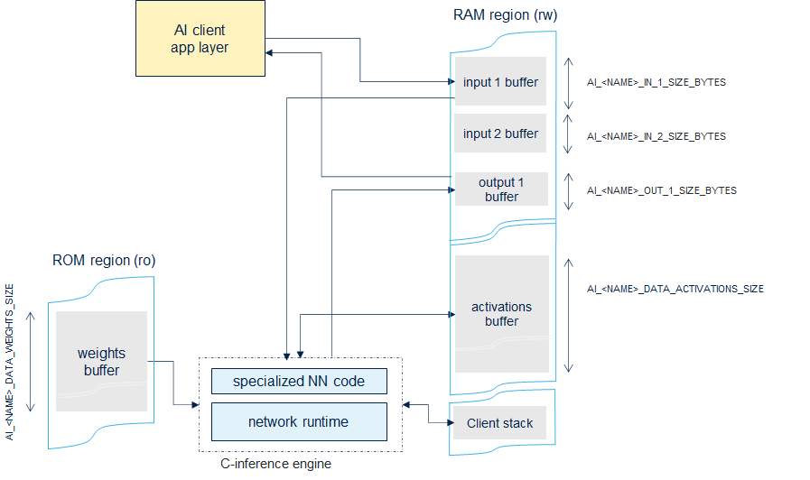

Figure 2: Default data memory layout

The kernels (inference runtime library) is executed in the context of the caller, the minimal requested **stack** size can be evaluated at run-time by the *aiSystemPerformance* application (refer to [[2], “AI system performance application”](https://www.st.com/resource/en/user_manual/dm00570145.pdf) section)

**Note** — Placement of these objects are application linker or/and runtime dependent. Additional ROM and RAM for the network runtime library and network c-file (txt/rodata/bss and data sections) are also linker dependent but are not considered as system dimensioning.

Following table indicates the privileged placement choices to minimize the inference time. According the model, the most constrained memory object is the “activations” buffer.

[output not shown]

## I/O buffers inside the “activations” buffer

The `'--allocate-inputs'` (respectively `'--allocate-outputs'`) option permits to use the “activations” buffer to allocate the data of the input tensors (respectively the output tensors). At generation time, the minimal size of the “activations” buffer is adapted accordingly. Be aware that the base addresses of the respective memory sub-regions are dependent of the model, they are not necessarily aligned with the base address of the “activations” buffer and are pre-defined/pre-calculated at generation time (see the snippet code to find them).

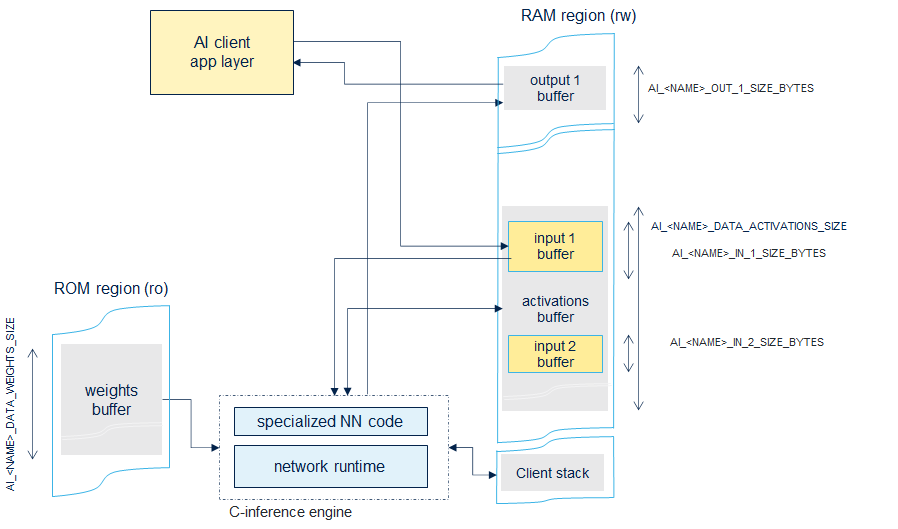

Figure 3: Data memory layout with `'--allocate-inputs'` option

- “external” input buffers (i.e. allocated outside the “activations” buffer) can be always used even if `'--allocate-inputs'` option is used.
- `'--allocate-inputs'` option reserves only the place for *one* buffer by input tensor.
- if a double buffer scheme should be implemented, `'--allocate-inputs'` flag should be not used.

## Split weights buffer

The `'--split-weights'` option is a convenience to be able to place statically tensor-by-tensor the weights in different STM32 memory device (on or off-chip) thanks to specific end-user application linker directives.

- it relaxes the placing constraint of a large buffer into a constrained and non-homogenous memory sub-system.
- after profiling, it allows to improve the global inference time, by placing the critical weights into a low latency memory. Or in contrary can free the critical resource (i.e. internal flash) which can be used by the application.

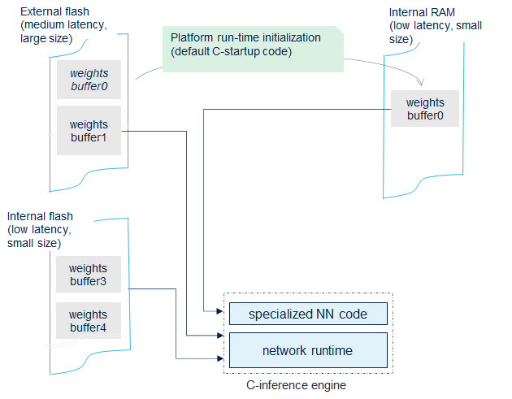

Figure 4: Split weights buffer (static placement)

The `'--split-weights'` option avoids to generate an unique c-array for the whole data of the weights/bias tensors (`'<name>_data.c'` file) as following:

```c
ai_handle ai_network_data_weights_get(void)
{
  AI_ALIGNED(4)
  static const ai_u8 s_network_weights[ 794136 ] = {
    0xcf, 0xae, 0x9d, 0x3d, 0x1b, 0x0c, 0xd1, 0xbd, 0x63, 0x99,
    0x36, 0xbd, 0xdb, 0x67, 0x46, 0xbe, 0x3b, 0xe7, 0x0d, 0x3e,
    ...
    0x41, 0xbf, 0xc6, 0x7d, 0x69, 0x3e, 0x18, 0x87, 0x37,
    0xbe, 0x83, 0x63, 0x0f, 0x3f, 0x51, 0xa1, 0xdd, 0xbe
  };
  return AI_HANDLE_PTR(s_network_weights);
}
```

A `'s_<network>_<layer_name>_[bias|weights|*]_array_weights[]'`) c-array is created to store the data of each weight/bias tensors. A global map table is also built, to be able to retrieve the addresses of the different c-arrays.

```c
...
/* conv2d_1_weights_array - FLOAT|CONST */
AI_ALIGNED(4)
const ai_u8 s_network_conv2d_1_weights_array_weights[ 2048 ] = {
  0xcf, 0xae, 0x9d, 0x3d, 0x1b, 0x0c, 0xd1, 0xbd, 0x63, 0x99,
...
}
...
/* dense_3_bias_array - FLOAT|CONST */
AI_ALIGNED(4)
const ai_u8 s_network_dense_3_bias_array_weights[ 24 ] = {
  0xa2, 0x72, 0x82, 0x3e, 0x5a, 0x88, 0x41, 0xbf, 0xc6, 0x7d,
  0x69, 0x3e, 0x18, 0x87, 0x37, 0xbe, 0x83, 0x63, 0x0f, 0x3f,
  0x51, 0xa1, 0xdd, 0xbe
};

/* Entry point to retrieve the address of the c-arrays */
ai_handle ai_network_data_weights_get(void) {
  static const ai_u8* const s_network_params_map_table[] = {
    &s_conv2d_1_weights_array_weights[0],
...
    &s_dense_3_bias_array_weights[0],
  };
  return AI_HANDLE_PTR(s_network_params_map_table);
};
```

- without particular linker directives, the placement of the multiple c-arrays are always placed in a `.rodata` section as for the unique c-array.
- client API is not changed. the `'ai_network_data_weights_get()'` function is used to pass the entry point of the weights buffer to the `'ai_<name>_init()'` function.
- as illustrated in the figure 4, `'const'` C-attribute can be manually commented to use the default C-startup behavior to copy a data in an initialized RAM data section.

## Re-entrance and thread safety considerations

No internal synchronization mechanism is implemented to protect the entry points against concurrent accesses. If the API is used in a multi-threaded context, the protection of the instantiated NN(s) must be guaranteed by the application layer itself. To minimize the usage of the RAM, a same activation memory chunk (SizeSHARED) can be used to support multiple network. In this case, the user must guarantee that an on-going inference execution cannot be preempted by the execution of another network.

```c
SizeSHARED = MAX(AI_<name>_DATA_ACTIVATIONS_SIZE) for name = “net1” … “net2”
```

**Note** — If the preemption is expected for real-time constraint or latency reasons, each network instance must have its own and private activation buffer.

## Debug support

The library must be considered as an optimized black box in binary format (sources files are not deliveries). There is no support for run-time internal data or state introspection. Mapping and port of the NN is guaranteed by the XCUBE-AI generator. Some integration issues can be highlighted by the `'ai_<name>_get_error()`’ function or by the usage of the Platform observer API to inspect the intermediate results.

# Embedded Client API

## `AI_<NAME>_XXX` C-defines

Different C-defines are generated in the `<name>.h` and `<name>_data.h` files. They can be used to retrieve the dimensioning values for C-compile time or dynamic allocation, or for debug purpose.

| C-defines | description |
| --- | --- |
| `AI_<NAME>_MODEL_NAME` | C-string with the C-name of the model |
| `AI_<NAME>_IN/OUT_NUM` | indicates the total number of input/output tensors |
| `AI_<NAME>_IN/OUT` | C-table (`'ai_buffer'` type) to describe the input/output tensors (see `'ai_<name>_run()'` function) |
| `AI_<NAME>_IN/OUT_SIZE` | C-table (integer type) to indicate the number of item by input/output tensors (= H x W x C) (see “Input/output xD tensor format” section) |
| `AI_<NAME>_IN/OUT_1_SIZE` | indicates the total number of item for the first input/output tensor |
| `AI_<NAME>_IN/OUT_1_SIZE_BYTES` | indicates the size in bytes for the first input/output tensor (see `'ai_<name>_run()'` function) |
| `AI_<NAME>_DATA_ACTIVATIONS_SIZE` | indicates the minimal size in bytes which must provided by a client application layer as working buffer (see `'ai_<name>_init()'` function) |
| `AI_<NAME>_DATA__WEIGHTS_SIZE` | indicates the size in bytes of the generated weights/bias buffer segment |
| `AI_<NAME>_INPUTS_IN_ACTIVATIONS` | indicates that the input buffers can be used from the activations buffer. It is *only* defined if the `'--allocate-inputs'` option is used. |
| `AI_<NAME>_OUTPUTS_IN_ACTIVATIONS` | indicates that the outputs buffers can be used from the activations buffer. It is *only* defined if the `'--allocate-outputs'` option is used. |

## `ai_<name>_create()`

```cpp
ai_error ai_<name>_create(ai_handle* network, const ai_buffer* network_config);
ai_handle ai_<name>_destroy(ai_handle network);
```

This **mandatory** function is the *early* function which must be called by the application to create an instance of the neural network. Provided `'ai_handle'` object is updated and it references a context (opaque object) which should be passed to the other functions.

- The `'network_config'` parameter is a specific network configuration buffer (opaque structure) coded as a `'ai_buffer'`. It is normally generated by the code generator and should be *not modified* by the application. For the current supported STM32 series and model, this object is always empty and `NULL` can be passed but it is preferable to pass `'AI_NETWORK_DATA_CONFIG'` (see `'<name>.h'` file).

When the instance is no more used by the application, `'ai_<name>_destroy()'` function should be called to release the possible allocated resources.

**Warning** — the STM32 CRC IP clock should be enabled before to call the `ai_<network>_XXX()` functions else the application hangs.

## `ai_<name>_init()`

```cpp
ai_bool ai_<name>_init(ai_handle network, const ai_network_params* params);
```

This **mandatory** function is used by the application to initialize the internal run-time data structures and to set the activations buffer and weights buffer.

- `params` parameter is a structure (`ai_network_params` type) which allows to pass the references of the generated weights (`params` field) and the activation/crash memory buffer (`activations` field)
- `network` handle should be a valid handle, see `'ai_<name>_create()'` function

```c
/* @file: ai_platform.h */
typedef struct ai_network_params_ {
  ai_buffer   params;         /*! info about params buffer(required!) */
  ai_buffer   activations;    /*! info about activations buffer (required!) */
} ai_network_params;
```

- `params` attribute handles the weights/bias memory buffer
- `activations` attribute handles the activations buffer which is used by the inference engine.
- size of associated memory blocks are respectively defined by the following C-defines (see `<name>_data.h` file).
  - `AI_<NAME>_DATA_WEIGHTS_SIZE`
  - `AI_<NAME>_DATA_ACTIVATIONS_SIZE`

> Memory layout of the weights/activation buffers are fully dependent of the implemented neural network.

`AI_NETWORK_DATA_WEIGHTS()`and `AI_NETWORK_DATA_ACTIVATIONS()` helper macros should be used to populate the requested `params` structure. Note that the `ai_network_data_weights_get()` functions allows to retrieve the base address of the weights buffer (see `'<network>_data.h'` file).

```c
AI_ALIGNED(4)
static ai_u8 activations[AI_NETWORK_DATA_ACTIVATIONS_SIZE];

const ai_network_params params = {
  AI_NETWORK_DATA_WEIGHTS(ai_network_data_weights_get()),
  AI_NETWORK_DATA_ACTIVATIONS(activations) };

ai_network_init(network, &params);
```

## `ai_<name>_run()`

```cpp
ai_i32 ai_<name>_run(ai_handle network, const ai_buffer* input, ai_buffer* output);
```

This function is called to feed the neural network. The input and output buffer parameters (`'ai_buffer'` type) allow to provide the input tensors and to store the predicted output tensors respectively (see “Input/output xD tensor format” section).

- Returned value is the number of the input tensors processed when n_batches >= 1. If <=0 ,`'ai_network_get_error()'` function should be used to know the error

**NOTE** — Two separate lists of inputs and outputs `'ai_buffer'` can be passed. This permits to support a neural network model with multiple inputs or/and outputs. `'AI_NETWORK_IN_NUM'` and respectively `'AI_NETWORK_OUT_NUM'` helper macro can be used to know at compile-time the number of inputs and outputs. These values are also returned by the `"struct ai_network_report"` (see `'ai_<name>_get_info()'` function).

### Typical usages

Default UC is illustrated by the “Getting starting” code snippet. Following code is an example with a C-model which has two input and two output tensors. Note that the data payload of the input buffers are also used in the “activations” buffer.

```c
#include <stdio.h>
#include "network.h"
...
/* @ of the input buffers */
static ai_float *in_data[AI_NETWORK_IN_NUM];

/* ai input handlers */
static ai_buffer ai_inputs[AI_NETWORK_IN_NUM] = AI_NETWORK_IN ;

/* ai output handlers */
static ai_buffer ai_outputs[AI_NETWORK_OUT_NUM] = AI_NETWORK_OUT ;

/* data buffer for the output buffers */
static ai_float out_1_data[AI_NETWORK_OUT_1_SIZE];
static ai_float out_2_data[AI_NETWORK_OUT_2_SIZE];

/* @ of the output buffers */
static ai_float* out_data[AI_NETWORK_OUT_NUM] = {
  &out_1_data[0],
  &out_2_data[0]
  }

...
int aiInit(void) {
  ...
  ai_network_report report;

  /* 1 - Create and initialize network */
  ...

  /* 2 - Retrieve network infos */
  ai_network_get_info(network, &report);

  /* 3 - Update the ai input handlers with the effective @ of
         the input buffers  */
  for (int i=0; i < AI_NETWORK_IN_NUM; i++) {
    ai_inputs[i].n_batches = 1;
    ai_inputs[i].data = AI_HANDLE_PTR(report.inputs[i].data);
    in_data[i] = (ai_u8 *)(ai_inputs[i].data);
  }

  /* 4- Update the ai output handlers */
  for (int i=0; i < AI_NETWORK_OUT_NUM; i++) {
    ai_inputs[i].n_batches = 1;
    ai_inputs[i].data = AI_HANDLE_PTR(&out_data[i]);
  }
  ...
}

void main_loop()
{
  while (1) {
    /* 1 - Acquire, pre-process and fill the input buffers */
    acquire_and_process_data(&in_data[0], &in_data[1]);

    /* 2 - Call inference engine */
    ai_network_run(network, &ai_inputs[0], &ai_outputs[0]);

    /* 3 - Post-process the predictions */
    post_process(&out_data[0], &out_data[1]);
  }
}
```

## `ai_<name>_get_error()`

```cpp
ai_error ai_<name>_get_error(ai_handle network);
```

This function can be used by the client application to retrieve the 1st error reported during the execution of a `'ai_<name>_xxx()'` function.

- See `ai_platform.h` file to have the list of the returned error type (`'ai_error_type'`) and associated code (`'ai_error_code'`).

### Typical AI error function handler (debug/log purpose)

```c
#include "network.h"
...
void aiLogErr(const ai_error err)
{
  printf("E: AI error - type=%d code=%d\r\n", err.type, err.code);
}
```

## `ai_<name>_get_info()`

```cpp
ai_bool ai_<name>_get_info(ai_handle network, ai_network_report* report);
```

This function allows to retrieve the run-time data attributes of an instantiated model. Refer to `'ai_platform.h'` file to show the detail of the returned `'ai_network_report'` C-struct. It should be called after the call of `'ai_<name>_init()'`.

### Typical usage

```c
#include "network.h"
...
int aiInit(void) {
  ai_network_report report;
  ai_bool res;
...
  res = ai_network_get_info(network, &report)
  if (res) {
    /* display/use the reported data */
    ...
  }
...
}
```

# IO buffer/tensor description

Up-to 4-dimensional tensors are supported with a fixed representation: **BHWC** format or *channel last* format representation. They are handled by a `'struct ai_buffer'` C-struct object. The referenced payload/data memory segment (`'data'` field) is physically stored and referenced in memory as a simple standard C-array type. Scattered memory buffers are not supported. `'format'` indicates the format of the data. `'meta_info'` is an extra field to reference the additional data-dependent parameters which can be requested to handle a buffer.

## ai_buffer C-struct

```c
/* @file: ai_platform.h */

typedef struct ai_buffer_ {
  ai_buffer_format        format;     /*!< buffer format */
  ai_u16                  n_batches;  /*!< number of batches in the buffer */
  ai_u16                  height;     /*!< buffer height dimension */
  ai_u16                  width;      /*!< buffer width dimension */
  ai_u32                  channels;   /*!< buffer number of channels */
  ai_handle               data;       /*!< pointer to buffer data */
  ai_buffer_meta_info*    meta_info;  /*!< pointer to buffer metadata info */
} ai_buffer;
```

Following table shows the expected mapping of the 1d, 2d and 3d-array tensor:

| tensor shape | mapped on (B, H, W, C) |
| --- | --- |
| 1d-array | (-, 1, 1, c) |
| 2d-array | (-, h, 1, c) |
| 3d-array | (-, h, w, c) |

### Retrieve tensor information

Following code snippets show how to retrieve the tensor information from a buffer descriptor. `'format'` and `'meta_info'` fields are described in the next section.

```c
#include "network.h"

{
  /* Use the generated macro to set the buffer input descriptors */
  const ai_buffer input[] = AI_NETWORK_IN;

  /* Extract format of the first input tensor (index 0) */
  const ai_buffer_format fmt_1 = AI_BUFFER_FORMAT(&input[0]);

  /* Extract height, width and channels of the first input tensor */
  const ai_u16 height_1 = AI_BUFFER_HEIGHT(&input[0]);
  const ai_u16 width_1 = AI_BUFFER_WIDTH(&input[0]);
  const ai_u16 ch_1 = AI_BUFFER_CHANNELS(&input[0]);
  const ai_u16 size_1 = AI_BUFFER_SIZE(&input[0]);
  ...
}
```

or with the `'ai_network_info'` structure

```c
#include "network.h"

{
  /* Fetch run-time network descriptor */
  ai_network_report report;
  ai_network_get_info(network, &report);

  /* Set the descriptor of the first input tensor (index 0) */
  const ai_buffer *input = &report.inputs[0]

  /* Extract format of the tensor */
  const ai_buffer_format fmt_1 = AI_BUFFER_FORMAT(input);

  /* Extract height, width and channels of the tensor */
  const ai_u16 height_1 = AI_BUFFER_HEIGHT(input);
  const ai_u16 width_1 = AI_BUFFER_WIDTH(input);
  const ai_u16 ch_1 = AI_BUFFER_CHANNELS(input);
  const ai_u16 size_1 = AI_BUFFER_SIZE(input);
  ...
}
```

## Tensor format

The format of the data is mainly defined by the field `'format'`, a 32b word (`'ai_buffer_format'` type). Two types are supported.

```c
const ai_buffer_format fmt = AI_BUFFER_FORMAT(@ai_buffer_object);
```

[output not shown]

### Helper C-macros

Following set of C-macros can be used with the `'format'` field from a `'struct ai_buffer'` C-struct object to extract the information.

| macros | description |
| --- | --- |
| `AI_BUFFER_FMT_GET_TYPE(fmt)` | returns `'AI_BUFFER_FMT_TYPE_FLOAT'` or `'AI_BUFFER_FMT_TYPE_Q'` buffer type |
| `AI_BUFFER_FMT_GET_FLOAT(fmt)` | returns `'1'` if the data is a float type else `'0'` |
| `AI_BUFFER_FMT_GET_SIGN(fmt)` | returns `'1'` if the data is signed else `'0'`. |
| `AI_BUFFER_FMT_GET_BITS(fmt)` | returns the total number of bit which is used to encode the data. This is M+N+sign for `'AI_BUFFER_FMT_TYPE_Q'` type. Available values: `'32'` or `'8'` |
| `AI_BUFFER_FMT_GET_FBITS(fmt)` | returns the total number of bit which is used to encode the fractional part for the 8b quantized data type. |

Additional macros are defined for the meta parameters:

```c
const ai_buffer_meta_info * meta_info = AI_BUFFER_META_INFO(@ai_buffer_object);
```

[output not shown]

**NOTE** — Be aware that the `'meta_info'` field is only available through the returned `'ai_network_report()'` structure. Otherwise the value defined by the generated `'AI_<NAME>_IN/OUT'` C-define are `'NULL'`.

Following code snippet illustrates a typical code to extract the `'m,n'` values.

```c
#include "network.h"

{
  /* Use the generated macro to set the buffer input descriptors */
  const ai_buffer input[] = AI_NETWORK_IN;

  /* Extract format of the first input tensor (index 0) */
  const ai_buffer_format fmt_1 = AI_BUFFER_FORMAT(&input[0]);

  /* Extract the data type */
  const uint32_t type = AI_BUFFER_FMT_GET_TYPE(fmt_1); /* -> AI_BUFFER_FMT_TYPE_Q */

  /* Extract m,n values */
  const ai_size sign = AI_BUFFER_FMT_GET_SIGN(fmt_1);  /* -> 1 */
  const ai_size bits = AI_BUFFER_FMT_GET_BITS(fmt_1);  /* -> 8 */

  const ai_i16 N = AI_BUFFER_FMT_GET_FBITS(fmt_1);
  const ai_size M = bits - sign - N;
  ...
}
```

Extraction of the `'scale'` and `'zero_point'` values are showed by the following snippet code:

```c
#include "network.h"

static ai_handle network;

{
  /* Fetch run-time network descriptor. This is MANDATORY
     to retrieve the meta parameters. They are NOT available
     with the definition of the AI_<NAME>_IN/OUT macro.
  */
  ai_network_report report;
  ai_network_get_info(network, &report);

  /* Set the descriptor of the first input tensor (index 0) */
  const ai_buffer *input = &report.inputs[0]

  /* Extract format of the tensor */
  const ai_buffer_format fmt_1 = AI_BUFFER_FORMAT(input);

  /* Extract the data type */
  const uint32_t type = AI_BUFFER_FMT_GET_TYPE(fmt_1); /* -> AI_BUFFER_FMT_TYPE_Q */

  /* Extract sign and number of bits */
  const ai_size sign = AI_BUFFER_FMT_GET_SIGN(fmt_1);  /* -> 1 or 0*/
  const ai_size bits = AI_BUFFER_FMT_GET_BITS(fmt_1);  /* -> 8 */

  /* Extract scale/zero_point values (only pos=0 is currently supported, per-tensor) */
  const ai_float scale = AI_BUFFER_META_INFO_INTQ_GET_SCALE(input->meta_info, 0);
  const int zero_point = AI_BUFFER_META_INFO_INTQ_GET_ZEROPOINT(input->meta_info, 0);
  ...
}
```

Floating-point case.

```c
#include "network.h"

{
  /* Generated macro is used to set the buffer input descriptors */
  const ai_buffer input[] = AI_<NAME>_IN;

  /* Retrieve format of the first input tensor (index 0) */
  const ai_buffer_format fmt_1 = AI_BUFFER_FORMAT(&input[0]);

  /* Retrieve the data type */
  const uint32_t type = AI_BUFFER_FMT_GET_TYPE(fmt_1); /* -> AI_BUFFER_FMT_TYPE_FLOAT */

  /* Retrieve sign/size values */
  const ai_size sign = AI_BUFFER_FMT_GET_SIGN(fmt_1);   /* -> 1 */
  const ai_size bits = AI_BUFFER_FMT_GET_BITS(fmt_1);   /* -> 32 */
  const ai_size N = AI_BUFFER_FMT_GET_FBITS(fmt_1);     /* -> 0 */
  ...
}
```

## Life-cycle of the IO buffers

When the input buffers and output buffers are passed to the `'ai_<name>_run()'` function, the caller should wait the end of the inference to re-use the associated memory segments. There is no default mechanism to notify the application that the input tensors are released or no more used by the c-inference engine. This is particular true when the buffers are allocated in the activations buffer. But in the case where an input buffer is allocated in the user space and if the APP client known the `'c-id'` (refer to [3], *“C-graph description”* section) of the operator which processes the input, the Platform Observer API can be used to be notified when the operator has finished (see *“Processed input buffer notification use-case”* section).

## Base address of the IO buffers

To retrieve the addresses of the IO buffers allocated in the activations buffer when the `'--allocate-inputs'` (or `'--allocate-outputs'`) flag is used, the `ai_<name>_get_info()` function should be used. Note that the instance should be previously fully initialized, because the returned address is dependent to the base address of the provided activations buffer.

```c
#include "network.h"

static ai_handle network;

{
  ai_network_report report;
  ai_network_get_info(network, &report);

  /* Set the descriptor of the first input tensor (index 0) */
  const ai_buffer *input = &report.inputs[0];

  /* Retrieve the @ of the input buffer */
#if defined(AI_NETWORK_INPUTS_IN_ACTIVATIONS)
  ai_u8 *in_data_1 = (ai_u8 *)input->data;
#else
  /* Buffer should be allocated by the application
     in this case: input->data == NULL */
  ai_u8 in_data_1[AI_NETWORK_IN_1_SIZE_BYTES];
#endif
...
}
```

Note that the provided `AI_NETWORK_INPUTS_IN_ACTIVATIONS` or/and `AI_NETWORK_OUTPUTS_IN_ACTIVATIONS` C-defines can be used to condition the code at compile time.

## Float to integer format conversion

Following code snippet illustrates the float (ai_float) to integer (ai_i8/ai_u8) format conversion. Input buffer is used as destination buffer.

```c
#include <network.h>

#define _MIN(x_, y_) \
    ( ((x_)<(y_)) ? (x_) : (y_) )

#define _MAX(x_, y_) \
    ( ((x_)>(y_)) ? (x_) : (y_) )

#define _CLAMP(x_, min_, max_, type_) \
    (type_) (_MIN(_MAX(x_, min_), max_))

#define _ROUND(v_, type_) \
    (type_) ( ((v_)<0) ? ((v_)-0.5f) : ((v_)+0.5f) )

const ai_buffer *get_input_desc(idx)
{
  ai_network_report report;
  ai_network_get_info(network, &report);
  return &report.inputs[idx];
}

ai_float input_f[AI_<NAME>_IN_1_SIZE];
ai_i8 input_q[AI_<NAME>_IN_1_SIZE]; /* or ai_u8 */

{
  const ai_buffer *input = get_input_desc(0);
  ai_float scale  = AI_BUFFER_META_INFO_INTQ_GET_SCALE(input->meta_info, 0);
  const ai_i32 zp = AI_BUFFER_META_INFO_INTQ_GET_ZEROPOINT(input->meta_info, 0);

  scale = 1.0f / scale;

  /* Loop */
  for (int i=0; i < AI_<NAME>_IN_1_SIZE; i++)
  {
    const ai_i32 tmp_ = zp + _ROUND(input_f[i] * scale, ai_i32);
    /* for ai_u8 */
    input_q[i] = _CLAMP(tmp_, 0, 255, ai_u8);
    /* for ai_i8 */
    input_q[i] = _CLAMP(tmp_, -128, 127, ai_i8);
  }
  ...
}
```

## Integer to float format conversion

Following code snippet illustrates the integer (ai_i8/ai_u8) to float (ai_float) format conversion. The output buffer is used as source buffer.

```c
#include <network.h>

ai_i8 output_q[AI_<NAME>_OUT_1_SIZE]; /* or ai_u8 */
ai_float output_f[AI_<NAME>_OUT_1_SIZE];

const ai_buffer *get_output_desc(idx)
{
  ai_network_report report;
  ai_network_get_info(network, &report);
  return &report.outputs[idx];
}

{
  const ai_buffer *output = get_output_desc(0);
  ai_float scale  = AI_BUFFER_META_INFO_INTQ_GET_SCALE(output->meta_info, 0);
  const ai_i32 zp = AI_BUFFER_META_INFO_INTQ_GET_ZEROPOINT(output->meta_info, 0);

  /* Loop */
  for (int i=0; i<AI_<NAME>_OUT_1_SIZE; i++)
  {
    output_f[i] = scale * ((ai_float)(output_q[i]) - zp);
  }
  ...
}
```

## Float to Qmn format conversion

Following code snippet illustrates the float (ai_float) to Qmn (ai_i8) format conversion. The input tensor is used as destination buffer.

```c
#include "network.h"

#define _MIN(x_, y_) \
  ( ((x_)<(y_)) ? (x_) : (y_) )

#define _MAX(x_, y_) \
  ( ((x_)>(y_)) ? (x_) : (y_) )

#define _CLAMP(x_, min_, max_, type_) \
  (type_) (_MIN(_MAX(x_, min_), max_))

#define _ROUND(v_, type_) \
  (type_) ( ((v_)<0) ? ((v_)-0.5f) : ((v_)+0.5f) )

ai_float input_f[AI_<NAME>_IN_1_SIZE];
ai_i8 input_q[AI_<NAME>_IN_1_SIZE];

{
  const ai_buffer input[] = AI_<NAME>_IN;

  /* Retrieve format of the output tensor - index 0 */
  const ai_buffer_format fmt_ = AI_BUFFER_FORMAT(&input[0]);

  /* Build the scale factor for conversion */
  const ai_float scale = (0x1U << AI_BUFFER_FMT_GET_FBITS(fmt_));

  /* Loop */
  for (int i=0; i < AI_<NAME>_IN_1_SIZE; i++)
  {
    const ai_i32 tmp_ = _ROUND((input_f[i] * scale), ai_i32);
    input_q[i] = _CLAMP(tmp_, -128, 127, ai_i8);
  }
  ...
}
```

## Qmn to float format conversion

Following code snippet illustrates the Qmn (ai_i8) to FLOAT (ai_float) format conversion. The output tensor is used as source buffer.

```c
#include "network.h"

ai_i8 output_q[AI_<NAME>_OUT_1_SIZE];
ai_float output_f[AI_<NAME>_OUT_1_SIZE];

{
  const ai_buffer output[] = AI_<NAME>_OUT;

  /* Retrieve format of the output tensor - index 0 */
  const ai_buffer_format fmt_1 = AI_BUFFER_FORMAT(&output[0]);

  /* Build the scale factor for conversion */
  const ai_float scale = 1.0f / (0x1U << AI_BUFFER_FMT_GET_FBITS(fmt_1));

  /* Loop */
  for (int i=0; i<AI_<NAME>_OUT_1_SIZE; i++)
  {
    output_f[i] = (ai_float)(output_q[i]) * scale;
  }
  ...
}
```

## 1d-array tensor

For a `1-D tensor`, standard C-array type is expected to handle the input and output tensors.

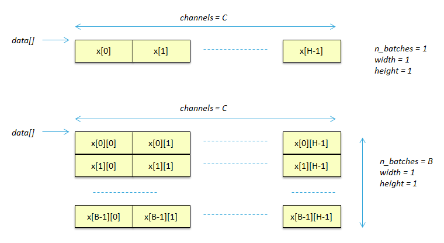

Figure 1: 1-D Tensor data layout

```c
#include "network.h"

#define xx_SIZE  VAL  /* = H * W * C = C */

ai_float xx_data[xx_SIZE];     /* n_batch = 1, height = 1, width = 1, channels = C */

ai_float xx_data[B * xx_SIZE]; /* n_batch = B, height = 1, width = 1, channels = C */
ai_float xx_data[B][xx_SIZE];
```

## 2d-array tensor

For a `2-D tensor`, standard C-array-of-array memory arrangement is used to handle the input and output tensors. 2-dim are mapped to the first two dimensions of the tensor in the original toolbox representation: e.g. H and C in Keras / Tensorflow, H and W in Lasagne.

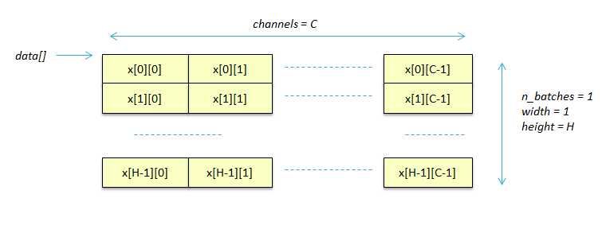

Figure 2: 2-D Tensor data layout

```c
#include "network.h"

#define xx_SIZE  VAL  /* = H * W * C = H * C */

ai_float xx_data[xx_SIZE];  /* n_batch = 1, height = H, width = 1, channels = C */
ai_float xx_data[H][C];

ai_float xx_data[B * xx_SIZE]; /* n_batch = B, height = H, width = 1, channels = C */
ai_float xx_data[B][H][C];
```

**NOTE** — If the dimension order in the original toolbox is different from HWC (e.g. Lasagne: CHW) it’s up to the application to properly re-arrange the element order

## 3d-array tensor

For a `3D-tensor`, standard C-array-of-array-of-array memory arrangement is used to handle the input and output tensors.

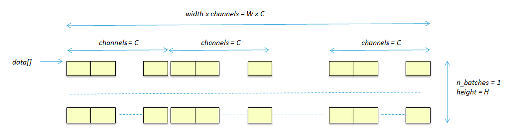

Figure 3: 3-D Tensor data layout

```c
#include "network.h"

#define xx_SIZE  VAL  /* = H * W * C */

ai_float xx_data[xx_SIZE];  /* n_batch = 1, height = H, width = W, channels = C */
ai_float xx_data[H][W][C];

ai_float xx_data[B * xx_SIZE]; /* n_batch = B, height = H, width = W, channels = C */
ai_float xx_data[B][H][W][C];
```

# Platform Observer API

For advanced run-time, debug or profiling purposes, an AI client can register a call-back function to be notified before or/end after the execution of a c-node. As detailed in the *“C-graph description”* section from [3], each node is identified by its executing index: `'c-id'`. The call-back can be used to measure the execution time or/and to dump the intermediate values.

## User call-back registration for profiling use-case

Previous minimal code snippet is updated to register a basic call-back function that logs the number of used core cycles after each executing of a node (More advanced implementation can be found in `'aiSystemPerformance.c'` file).

```c
#include "ai_platform_interface.h"
...
/*
 * Observer initialization
 */

/* Minimal ctx to store the timestamp (before execution) */
struct u_observer_ctx {
  uint64_t ts;
  uint32_t n_events;
};

struct u_observer_ctx u_observer_ctx;

static ai_u32 u_observer_cb(const ai_handle cookie,
    const ai_u32 flags,
    const ai_observer_node *node) {

  uint64_t ts = dwtGetCycles();  /* time stamp entry */
  struct u_observer_ctx *ctx = (u_observer_ctx *)cookie;

  if (flags & AI_OBSERVER_POST_EVT) {
    printf("%d - cpu cycles: %lld\r\n", node->c_idx, ts - ctx->ts);
    ctx->n_events++;
  }
  ctx->ts = dwtGetCycles(); /* time stamp exit */
  return 0;
}

/* Register a call-back to be notified before
   and after each executing of a c-node */
int aiObserverSetup() {

  if (!ai_platform_observer_register(network,
     u_observer_cb, &u_observer_ctx,
     AI_OBSERVER_PRE_EVT | AI_OBSERVER_POST_EVT)) {
    err = ai_network_get_error(network);
    printf("E: AI ai_platform_observer_register error - type=%d code=%d\r\n", err.type, err.code);
    return -1;
  }
  return 0;
}
```

**NOTE** — As for the `'ai_<network>_run()'` function, the registered callback function is executed synchronously in the context of the caller.

## Node-per-node inspection

The `'ai_platform_observer_node_info()'` function can be used to pass through the executing C-graph structure retrieving the tensor attributes node-per-node. A set of helper macros (`'AI_TENSOR_XXX'` from `'ai_platform_interface.h'` file) should be used to retrieve or to manipulate the returned tensor object: `'t'`.

```c
#include "ai_platform_interface.h"

{
  ai_observer_node node_info;
  ai_tensor_list *tl;

  node_info.c_idx = 0; /* starting with the first node */
  while (ai_platform_observer_node_info(network, &node_info)) {
    /* Check if the node is a "Time Distributed" operator. In this
     * case, weight/bias tensors are provided through the inner object
     * - node_info.inner_tensors != NULL condition can be also used
     */
    const ai_bool is_time_dist = (node_info.type & 0x8000 != 0);
    node_info.type &= 0x7FFF;
    /* Retrieve the list of the input tensors */
    tl = GET_TENSOR_LIST_IN(node_info.tensors);
    if (tl) {
      AI_FOR_EACH_TENSOR_LIST_DO(i, t, tl) {
        ...
      }
    }
    /* Retrieve the list of the output tensors */
    tl = GET_TENSOR_LIST_OUT(node_info.tensors);
    if (tl) {
      AI_FOR_EACH_TENSOR_LIST_DO(i, t, tl) {
        ...
      }
    }
    /* Retrieve the list of the weight/bias tensors */
    if (is_time_dist)
      tl = GET_TENSOR_LIST_WEIGTHS(node_info.inner_tensors);
    else
      tl = GET_TENSOR_LIST_WEIGTHS(node_info.tensors);
    if (tl) {
      AI_FOR_EACH_TENSOR_LIST_DO(i, t, tl) {
        ...
      }
    }
    /* Retrieve the list of the scratch tensors */
    if (is_time_dist)
      tl = GET_TENSOR_LIST_SCRATCH(node_info.inner_tensors);
    else
      tl = GET_TENSOR_LIST_SCRATCH(node_info.tensors);
    if (tl) {
      AI_FOR_EACH_TENSOR_LIST_DO(i, t, tl) {
        ...
      }
    }
    node_info.c_idx++;
  } /* end of the while loop */
  ...
}
```

| macro | description |
| --- | --- |
| `AI_TENSOR_ARRAY_BYTE_SIZE(t)` | returns the size in byte of the data buffer. |
| `AI_TENSOR_ARRAY_GET_DATA_ADDR(t)` | returns the effective address of the data buffer. |
| `AI_TENSOR_ARRAY_UPDATE_DATA_ADDR(t, addr)` | set a new effective address. It should be 4-bytes aligned. Previous address is forgotten and not saved (see next section). |

**Warning** – `'ai_platform_observer_node_info()'` should be called with an initialized instance to be sure to have a complete and ready-to-use initialization of the internal runtime data structure (in particular the arrays objects which handle the data of the tensors).

## Copy-before-run use-case

Kernels from the network runtime library are designed to take account flexible data placement, thanks to the usage of the scratch buffers or stack-based technics. After profiling session, and if a static placement approach (based on the `'--split-weights'` option) is not sufficient or adapted, it is also possible to improve the inference time, by *copy-before-run* the critical weights/bias data buffer in a low latency memory.

Following code snippet illustrates the usage of a software “cache” memory to store the weights/bias of a specific critical layer before to call the `'ai_<name>_run()'` function. Particular compiler directive (tool-chain dependent) can be used to place `'_w_cache'` object.

```c
#include <string.h>
#include "ai_platform_interface.h"

#define ALIGN_UP(num, align) \
    (((num) + ((align) - 1)) & ~((align) - 1))

AI_ALIGN(4)
static ai_u8 _w_cache[XXX]; /* reserve buffer to cache the weights */

int aiCacheWeights(void) {
  ai_observer_node node_info;
  node_info.c_idx = ID; /* index of the critical node */
  if (ai_platform_observer_node_info(network, &node_info)) {
    ai_tensor_list *tl;
    tl = GET_TENSOR_LIST_WEIGTHS(node_info.tensors);
    uintptr_t dst_addr = (uintptr_t)&_w_cache[0];
    AI_FOR_EACH_TENSOR_LIST_DO(i, t, tl) {
        /* Retrieve the @/size of the data */
        const uintptr_t src_addr = (uintptr_t)AI_TENSOR_ARRAY_GET_DATA_ADDR(t);
        const ai_size sz = AI_TENSOR_ARRAY_BYTE_SIZE(t);
        /* Copy the dta tensor in the SW cache */
        memcpy(dst_addr, src_addr, sz);
        /* set the new effective address */
        AI_TENSOR_ARRAY_UPDATE_DATA_ADDR(t, dst_addr);
        dst_addr += ALIGN_UP(sz, 4);
      }
  }
  return 0;
}
```

## Dumping intermediate output use-case

Following code snippet illustrates a simple call-back to dump an output of a given internal layer `'C_ID'`. Internal tensor description is converted to a `'ai_buffer`’-type data.

```c
#include "ai_platform_interface.h"
...

#define C_ID (12)  /* c-id of the operator which must be dumped */

static ai_u32 u_observer_cb(const ai_handle cookie,
    const ai_u32 flags,
    const ai_observer_node *node) {

    ai_tensor_list *tl;

    if (node->c_idx == C_ID) {
      tl = GET_TENSOR_LIST_OUT(node_info.tensors);
      AI_FOR_EACH_TENSOR_LIST_DO(i, t, tl) {
          /* Currently, only ONE output is supported */
          ai_buffer buffer;
          ai_float scale = AI_TENSOR_INTEGER_GET_SCALE(t, 0);
          ai_i32 zero_point = 0;

          if (AI_TENSOR_FMT_GET_SIGN(t))
            zero_point = AI_TENSOR_INTEGER_GET_ZEROPOINT_I8(t, 0);
          else
            zero_point = AI_TENSOR_INTEGER_GET_ZEROPOINT_U8(t, 0);

          buffer.format = AI_TENSOR_GET_FMT(t);
          buffer.n_batches = 1;
          buffer.data = AI_TENSOR_ARRAY_GET_DATA_ADDR(t);
          buffer.height = AI_SHAPE_H(AI_TENSOR_SHAPE(t));
          buffer.width = AI_SHAPE_W(AI_TENSOR_SHAPE(t));
          buffer.channels = AI_SHAPE_CH(AI_TENSOR_SHAPE(t));
          buffer.meta_info = NULL;
          ...
        }
      }
    }

  return 0;
}

...
/* registered call-back is only raised for the POST event */
ai_platform_observer_register(network,
     u_observer_cb, &u_observer_ctx, AI_OBSERVER_POST_EVT))
...
```

## End-of-process input buffer notification use-case

Following code snippet illustrates a simple call-back to notify the application when the input buffer is processed by a given layer `'C_ID'`. **Warning** the buffer should be not allocated in the activations buffer else there is no guarantee that the memory region will be not used by the other operators before the end of the inference. This can be use-full to anticipate a HW capture process (DMA-based) before the end of the inference.

```c
#include "ai_platform_interface.h"
...

#define C_ID (0)  /* c-id of the operator which processes the input buffer */

static ai_u32 u_observer_cb(const ai_handle cookie,
    const ai_u32 flags,
    const ai_observer_node *node) {

    if (node->c_idx == C_ID) {
      /* start a new capture process to fill the input buffer before the end-of
         inference */
        ...
    }

  return 0;
}

...
/* registered call-back is only raised for the POST event */
ai_platform_observer_register(network,
     u_observer_cb, &u_observer_ctx, AI_OBSERVER_POST_EVT))
...
```

## “ai_observer_node” definition

The `'ai_platform_observer_node_info()'` function and registered call-back function use the `'ai_observer_node'` data structure to report the tensor attributes for a given node: `'c_idx'`.

```c
/* @file ai_platform_interface.h */

typedef struct ai_observer_node_s {
  ai_u16            c_idx;   /*!< node index (position in the execution list) */
  ai_u16            type;    /*!< node type info */
  ai_u16            id;      /*!< node id assigned by code generator to reference the model layer */
  ai_u16            unused;  /*!< unused field for alignment */
  const ai_tensor_chain* inner_tensors; /*!< pointer to the inner tensors if available */
  const ai_tensor_chain* tensors;       /*!< pointer to a 4 sized array */
} ai_observer_node;
```

| field | description |
| --- | --- |
| c_idx | index of the associated c-node (also called c-id) |
| type | define the type of the c-operator (see `layers_list.h` file: `100XX` values). |
| id | index of the original operator from the imported model. |
| tensors | entry point to retrieve the list of [I], [O], [W] and [S] tensors. |
| inner_tensors | if the operator is a “Time Distributed” operator, [W] and [S] tensors are returned through this entry, else this field is NULL. |

If `'type & 0x8000 != 0'`, the associated operator is a “Time Distributed” operator and `'tensors'` and `'inner_tensors'` fields should be used to retrieve all of the tensors: [I], [O], [W] and [S] lists (see “Node-by-node inspection” section).

**Limitation** — `'inner_tensors'` field is always NULL and the most significant bit of `'type'` is not updated when the call-back is called.

## `ai_platform_observer_node_info()`

```cpp
ai_bool ai_platform_observer_node_info(
    ai_handle network, ai_observer_node *node_info);
```

This function populates the referenced `'ai_observer_node'` structure to retrieve the node and associated tensor attributes. Requested node index is defined through the `'node_info.c_idx'` field. If the `'network'` parameter is not a valid network instance or the index is out-of-range, `'ai_false'` is returned.

## `ai_platform_observer_register()`

```cpp
ai_bool ai_platform_observer_register(
    ai_handle network,
    ai_observer_node_cb cb,
    ai_handle cookie,
    ai_u32 flags););
ai_bool ai_platform_observer_unregister(ai_handle network,
    ai_observer_node_cb cb, ai_handle cookie);
```

This function registers an user call-back function. Only one call-back can be registered at a time by network instance.

- `'cb'` pointer of an user callback function (see “User call-back registration” code snippet)
- `'cookie'` reference of an user context/object which is returned without modification.
- `'flags'` bit-wise mask to indicate the type of requested events.

| flags | event type |
| --- | --- |
| `AI_OBSERVER_INIT_EVT` | initialization (at the end of the call of `'ai_<name>_init()'`) |
| `AI_OBSERVER_PRE_EVT` | before the execution of the kernel (during the call of `'ai_<name>_run()'`) |
| `AI_OBSERVER_POST_EVT` | after the execution of the kernel (during the call of `'ai_<name>_run()'`) |

```cpp
typedef ai_u32 (*ai_observer_node_cb)(const ai_handle cookie,
    const ai_u32 flags,
    const ai_observer_node *node)
```

When the call-back is called, the previous `'flags'` event types are extended with the following values:

| flags | event type |
| --- | --- |
| `AI_OBSERVER_FIRST_EVT` | event related to the first node. |
| `AI_OBSERVER_LAST_EVT` | event related to the last node. |

# References

| [1] | X-CUBE-AI - *AI expansion pack for STM32CubeMX* https://www.st.com/en/embedded-software/x-cube-ai.html |
| --- | --- |
| [2] | User manual - Getting started with X-CUBE-AI Expansion Package for Artificial Intelligence (AI) [(pdf)](https://www.st.com/resource/en/user_manual/dm00570145.pdf) |
| [3] | stm32ai - Command Line Interface (link) |
| [4] | Supported Deep Learning toolboxes and layers (link) |
| [5] | Embedded inference client API (link) |
| [6] | Evaluation report and metrics (link) |
| [7] | FAQs (link) |
| [8] | Quantization and quantize command (link) |
| [9] | Relocatable binary network support (link) |

# Revision history

| Date | version | changes |
| --- | --- | --- |
| **2019-06-14** | r1.0 | initial version |
| **2019-09-20** | r1.1 | X-CUBE-AI 4.1 update, add integer arithmetic support for quantized data. |
| **2019-12-03** | r1.2 | X-CUBE-AI 5.0 update, add allocate-inputs and multiple IO snippet code |
| **2020-05-18** | r2.0 | X-CUBE-AI 5.1 update, add platform observer API, add/complete data placement section, minor re-work and clean-up |
| **2020-06-11** | r2.1 | minor - add warning about the CRC IP clock |
| **2020-09-15** | r2.2 | X-CUBE-AI 5.2 update, allocate-outputs support, add new observer UCs, add some words about the re-entrance and debug aspects, fix typo |

Embedded Documentation - **Embedded Inference Client API**  
X-CUBE-AI Expansion Package  
r2.2 - AI PLATFORM r5.2.0 (Embedded Inference Client API 1.1.0) - Command Line Interface r1.4.0

Information in this document is provided solely in connection with ST products. The contents of this document are subject to change without prior notice.  
© Copyright STMicroelectronics 2020. All rights reserved. www.st.com